# 308.2. Solar System orbit classifications

For the Rubin Science Platform at data.lsst.cloud.  
Data Release: DP1  
Container Size: small  
LSST Science Pipelines version: r29.2.0  
Last verified to run: 2025-09-02  
Repository: github.com/lsst/tutorial-notebooks

**Learning objective:** An overview of the Data Preview 1 (DP1) Solar System object orbits.

**LSST data products:** `MPCORB`, `SSObject`

**Packages:** `lsst.rsp`

**Credit:** Originally developed by the Rubin Community Science team. Please consider acknowledging them if this notebook is used for the preparation of journal articles, software releases, or other notebooks.

**Get Support:** Everyone is encouraged to ask questions or raise issues in the [Support Category](https://community.lsst.org/c/support) of the Rubin Community Forum. Rubin staff will respond to all questions posted there.

## 1. Introduction

This notebook examines the orbital classifications of the DP1 Solar System object, including the DP1 discoveries. The DP1 data release contains 431 Solar System objects, 93 of those are discoveries.

Related tutorials: The 100-level tutorials demonstrate how to use the TAP service. The 200-level tutorials introduce the types of catalog data.

### 1.1. Import packages

Import `numpy`, a fundamental package for scientific computing with arrays in Python (numpy.org), and `matplotlib`, a comprehensive library for data visualization ([matplotlib.org](https://matplotlib.org/); [matplotlib gallery](https://matplotlib.org/stable/gallery/index.html)).

```python
import numpy as np
import pandas as pd
import matplotlib.pyplot as plt

from lsst.rsp import get_tap_service
```

### 1.2. Define parameters and functions

Create an instance of the TAP service, and assert that it exists.

```python
service = get_tap_service("tap")
assert service is not None
```

Define parameters to use colorblind-friendly colors with `matplotlib`.

```python
plt.style.use('seaborn-v0_8-colorblind')
prop_cycle = plt.rcParams['axes.prop_cycle']
colors = prop_cycle.by_key()['color']
```

```python
def calc_orbit_class(q, e):
    a = q / (1 - e)
    Q = a * (1 + e)

    orbit_class = np.full(len(a), "AST")

    orbit_class_dict = {
        "AMO": np.where((a > 1.0) & (q > 1.017) & (q < 1.3)),
        "APO": np.where((a > 1.0) & (q < 1.017)),
        "ATE": np.where((a < 1.0) & (Q > 0.983)),
        "CEN": np.where((a > 5.5) & (a < 30.1)),
        "IEO": np.where((Q < 0.983)),
        "IMB": np.where((a < 2.0) & (q > 1.666)),
        "MBA": np.where((a > 2.0) & (a < 3.2) & (q > 1.666)),
        "MCA": np.where((a < 3.2) & (q > 1.3) & (q < 1.666)),
        "OMB": np.where((a > 3.2) & (a < 4.6)),
        "TJN": np.where((a > 4.6) & (a < 5.5) & (e < 0.3)),
        "TNO": np.where((a > 30.1)),
        "PAA": np.where((e == 1)),
        "HYA": np.where((e > 1)),
    }
    for c, v in orbit_class_dict.items():
        orbit_class[v] = c

    return orbit_class
```

## 2. Classify orbits

Query the `MPCORB` table for the orbital parameters joined with the `SSObject` table to query for the `discoverySubmissionDate` for all DP1 Solar System objects.

```python
query = "SELECT mpc.ssObjectId, mpc.q, mpc.e, mpc.incl, "\
        "sso.discoverySubmissionDate "\
        "FROM dp1.MPCORB as mpc "\
        "INNER JOIN dp1.SSObject as sso "\
        "ON mpc.ssObjectId = sso.ssObjectId "\
        "ORDER BY mpc.ssObjectId"
```

```python
job = service.submit_job(query)
job.run()
job.wait(phases=['COMPLETED', 'ERROR'])
print('Job phase is', job.phase)
if job.phase == 'ERROR':
    job.raise_if_error()
```

```
Job phase is COMPLETED
```

Fetch the job results and assign to an astropy `result` table. There are 431 Solar System objects in DP1.

```python
assert job.phase == 'COMPLETED'
result = job.fetch_result()
print(len(result))
```

```
431
```

Convert the `result` astropy table to a pandas dataframe.

```python
result_df = pd.DataFrame(result)
```

Add a column to `result_df` with each object's `orbit_class`.

```python
result_df['orbit_class'] = calc_orbit_class(result_df['q'], result_df['e'])
```

Option to print the results

```python
# result_df
```

Find the objects with non-zero `discoverySubmissionDate`s. These are the Solar System objects discovered by Rubin. 93 of the 431 DP1 Solar System objects are discoveries.

```python
discoveries = result_df[result_df['discoverySubmissionDate'] > 0]
len(discoveries)
```

```
93
```

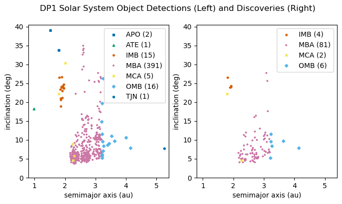

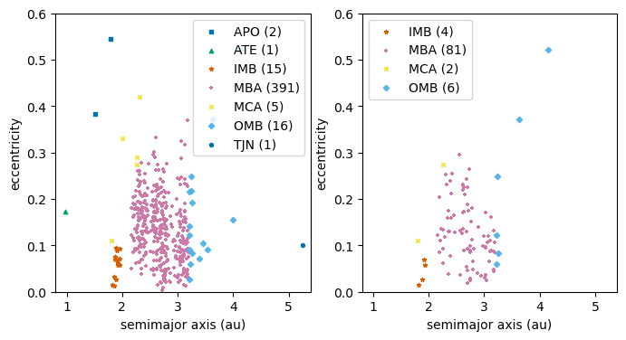

```python
fig, axes = plt.subplots(1, 2, figsize=(8, 4))

for ax, oo in zip(axes, (result_df, discoveries)):
    markers = "s^*+xDh"*2
    for label, orb in oo.groupby('orbit_class'):
        if len(orb) > 500:
            s, marker = 0.1, 'o'
        else:
            s = 10
            if label == 'APO':
                marker = "s"
                color = colors[0]
            elif label == 'ATE':
                marker = "^"
                color = colors[1]
            elif label == 'IMB':
                marker = "*"
                color = colors[2]
            elif label == 'MBA':
                marker = "+"
                color = colors[3]
            elif label == 'MCA':
                marker = "x"
                color = colors[4]
            elif label == 'OMB':
                marker = "D"
                color = colors[5]
            elif label == 'TJN':
                marker = "h"
                color = colors[0]
        ax.scatter((orb["q"]/(1-orb["e"])), orb["incl"],
                   s=s, marker=marker, color=color,
                   label=f"{label} ({len(orb)})")

    for handle in ax.legend().legend_handles:
        handle.set_sizes([10])
    ax.set_xlabel("semimajor axis (au)")
    ax.set_ylabel("inclination (deg)")
    ax.set_xlim([0.8, 5.4])
    ax.set_ylim([0, 40.5])

fig.suptitle("DP1 Solar System Object Detections (Left) and Discoveries (Right)")

fig, axes = plt.subplots(1, 2, figsize=(8, 4))

for ax, oo in zip(axes, (result_df, discoveries)):
    markers = "s^*+xDh"*2
    for label, orb in oo.groupby('orbit_class'):
        if len(orb) > 500:
            s, marker = 0.1, 'o'
        else:
            s = 10
            if label == 'APO':
                marker = "s"
                color = colors[0]
            elif label == 'ATE':
                marker = "^"
                color = colors[1]
            elif label == 'IMB':
                marker = "*"
                color = colors[2]
            elif label == 'MBA':
                marker = "+"
                color = colors[3]
            elif label == 'MCA':
                marker = "x"
                color = colors[4]
            elif label == 'OMB':
                marker = "D"
                color = colors[5]
            elif label == 'TJN':
                marker = "h"
                color = colors[0]
        ax.scatter((orb["q"]/(1-orb["e"])), orb["e"],
                   s=s, marker=marker, color=color,
                   label=f"{label} ({len(orb)})")

    for handle in ax.legend().legend_handles:
        handle.set_sizes([10])
    ax.set_xlabel("semimajor axis (au)")
    ax.set_ylabel("eccentricity")
    ax.set_xlim([0.8, 5.4])
    ax.set_ylim([0, 0.6])
```

> **Figure 1:** Semimajor axes, eccentricities, and inclinations of the 431 DP1 Solar System objects (left) and the 93 DP1 Solar System object discoveries (right), with the colors distinguishing each orbital class. The number of objects in each orbital class is indicated in the figure legends.

Clean up.

```python
del result, result_df, discoveries
```